# Master Data Science Data_VIZ

## 1. Informations sur les données

**Données:** liste des prénoms des enfants nés à Angers de 2013 à 2018 avec le nombre d’occurrences de chaque prénom,classés par année et par sexe.

**lien:** https://data.angers.fr/explore/dataset/prenoms-des-enfants-nes-a-angers/information/

**Définition des en-têtes:**

- COLL_NOM: nom de la commune
- COLL_INSEE: Code Insee de la commune
- ENFANT_SEXE: sexe
- ENFANT_PRENOM: prénom
- NOMBRE_OCCURENCES: occurrence du prénom
- ANNEE: année de naissance

```python
import pandas as pd

pd.set_option('display.max_rows', 500)
pd.set_option('display.max_columns', 500)

path = "/home/malick/Bureau/Data/Big_Data/Data_viz/prenoms-des-enfants-nes-a-angers.csv"
df = pd.read_csv(path,  sep=';')

df.iloc[1:11,2:6]
```

|  | ENFANT_SEXE | ENFANT_PRENOM | NOMBRE_OCCURENCES | ANNEE |
| --- | --- | --- | --- | --- |
| 1 | F | Apolline | 11 | 2017 |
| 2 | F | Cléa | 4 | 2017 |
| 3 | F | Maëlle | 4 | 2017 |
| 4 | F | Charlotte | 20 | 2018 |
| 5 | F | Alix | 7 | 2018 |
| 6 | F | Anaé | 6 | 2018 |
| 7 | M | Noham | 4 | 2013 |
| 8 | M | Marceau | 11 | 2015 |
| 9 | M | Yassine | 4 | 2015 |
| 10 | M | Eliott | 20 | 2016 |

## 2. Images, Histogrammes et Entropies:

Pour chaque variable, on importe deux images en couleur(respectant et ne respectant pas les préconisations de Mackinlay), on repasse ensuite les deux images en niveaux de gris et on récupére les histogrammes. Voici les fonctions permettant cela

```python
import matplotlib.image as mpimg
import matplotlib.pyplot as plt
import numpy as np
from sklearn.metrics.cluster import entropy # Calcul l'entropie d'une image



def rgb2gray(rgb):
    """ fonction qui convertit une image en gris """

    return np.dot(rgb[...,:3], [0.299, 0.587, 0.144])


def Entropie (image):
    """ fonction qui calcule l'entropie d'une image"""

    histogramme = np.histogram(img_1_gris.ravel(),256,[0,256],density=True)[0]
    return sum([-p*(math.log(p,2)) for p in histogramme if p > 0])


def Travailpersonnel(path):
    """fonction qui représente une image en couleur, en gris, trace l'histogramme et affiche son entropie"""

    img_1 = mpimg.imread(path)
    img_1_gris = rgb2gray(img_1)

    fig = plt.figure(1, figsize=(13, 13))


    plt.subplot(1, 2, 1)
    plt.title('Image originale')
    plt.imshow(img_1)

    plt.subplot(1, 2, 2)
    plt.title('Image en gris')
    plt.imshow(img_1_gris, cmap = plt.get_cmap('gray'))
    plt.show()

    fig = plt.figure(2, figsize=(10, 4))
    plt.subplot(1, 1, 1)
    plt.title('Histogramme')
    plt.hist(img_1_gris.ravel(),256,[0,256],density=True)

    plt.show()

    print("Entropie de l'image: ", round(entropy(img_1_gris),3))

path = "/home/malick/Bureau/Master_DS/Big_Data/Data_viz/Images"
```

#### a. ENFANT_SEXE (Attributs nominaux)

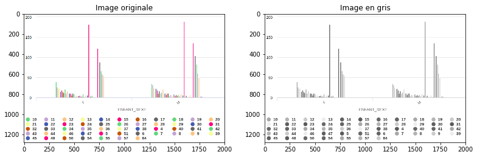

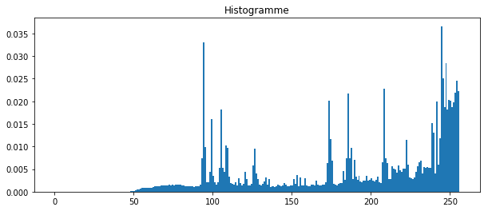

```
Entropie de l'image:  1.786
```

```python
im_1 = path + "/Colonnes_ENFANT_SEXE.jpg"
Travailpersonnel(im_1)
```

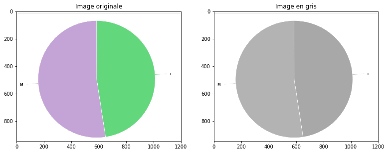

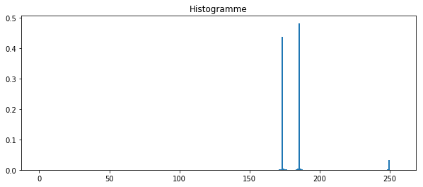

```
Entropie de l'image:  1.661
```

```python
im_2 = path + "/Camembert_ENFANT_SEXE.jpg"
Travailpersonnel(im_2)
```

#### b. ENFANT_PRENOM (Attributs nominaux)

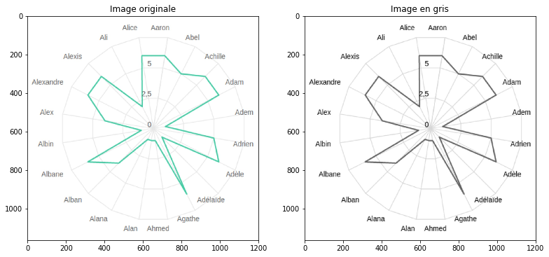

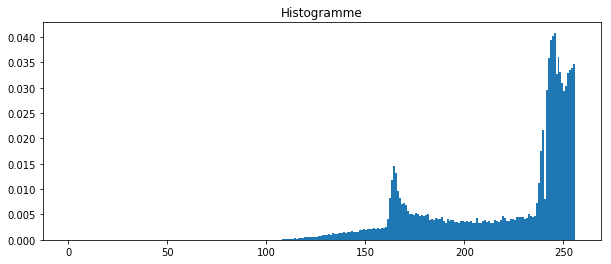

```
Entropie de l'image:  1.887
```

```python
im_1 = path + "/Radar_ENFANT_PRENOM.jpg"
Travailpersonnel(im_1)
```

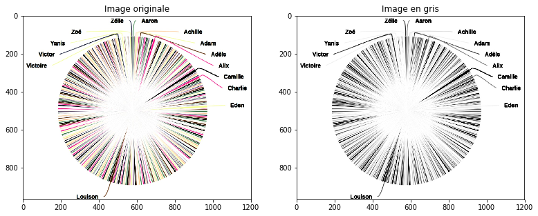

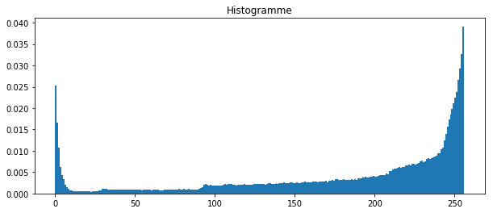

```
Entropie de l'image:  5.073
```

```python
im_2 = path + "/Camembert_ENFANT_PRENOM.jpg"
Travailpersonnel(im_2)
```

#### c. NOMBRE_OCCURENCES (Attributs quantitatifs, Attributs ordonnés)

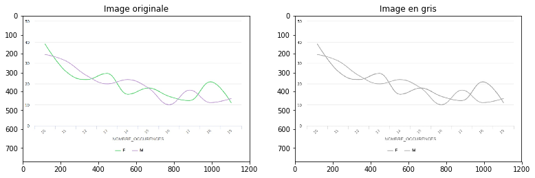

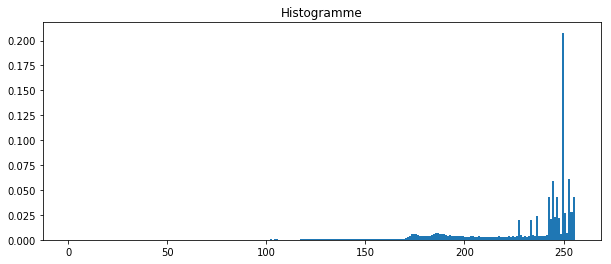

```
Entropie de l'image:  1.16
```

```python
im_1 = path + "/Courbe_NOMBRE_OCCURENCES.jpg"
Travailpersonnel(im_1)
```

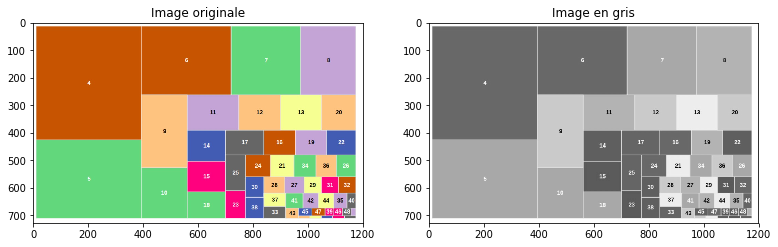

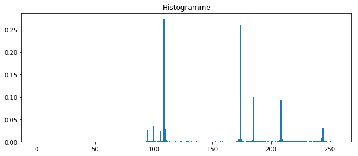

```
Entropie de l'image:  3.728
```

```python
im_2 = path + "/Treemap_NOMBRE_OCCURENCES.jpg"
Travailpersonnel(im_2)
```

#### d. ANNEE (Attributs quantitatifs, Attributs ordonnés)

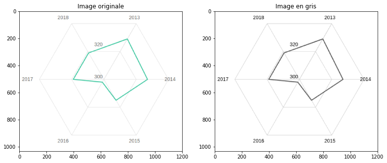

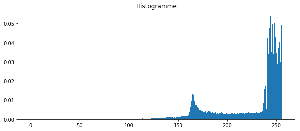

```
Entropie de l'image:  0.927
```

```python
im_1 = path + "/Radar_ANNEE.jpg"
Travailpersonnel(im_1)
```

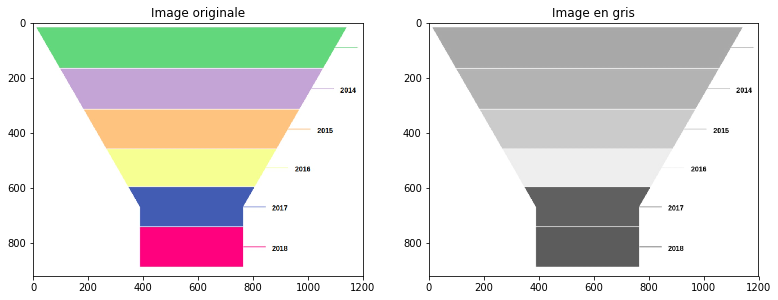

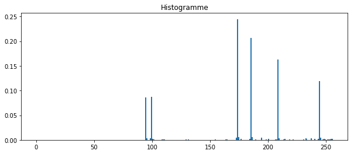

```
Entropie de l'image:  2.399
```

```python
im_2 = path + "/Entonnoir_ANNEE.jpg"
Travailpersonnel(im_2)
```

## 3. Conclusion:

Les deux plus faibles entropies ont été obtenues sur des graphes de type « Radar et Courbe ». Elles s’élèvent à 0.927 et 1.16. Ce soint des graphes qui sont peu chargés en couleurs et occupe trés peu d'espace dans l'image.

En conclusion, si le graphe est peu chargé en couleur et contient peu d’information en terme d’occupation de l’espace, alors son entropie est faible. Inversement, plus le graphe sera coloré et prendra la totalité de l’image (moins il y aura de fond blanc), plus l’entropie sera forte.